# Reproducible Research: Peer Assessment 1 - Andy Tinkham

```r
options(scipen = 999)
```

This assignment makes use of data from a personal activity monitoring device. This device collects data at 5 minute intervals throughout the day. The data consists of two months of data from an anonymous individual collected during the months of October and November, 2012 and includes the number of steps taken in 5 minute intervals each day.

## Loading and preprocessing the data

First, we need to read in the data (included in this same repository by default. If for some reason the file is missing, download it from the course web site).

```r
# if this file got separated from the data file, download the data file again
if (!file.exists("./activity.zip")) {
    fileUrl <- "https://d396qusza40orc.cloudfront.net/repdata%2Fdata%2Factivity.zip"
    download.file(fileUrl, destfile = "activity.zip", method = "curl")
    rm(fileUrl)
}

require(readr)
dataset <- read_csv("./activity.zip")
# Convert the interval to factors to make it easier to compare across days
dataset$interval <- factor(dataset$interval)
```

## What is mean total number of steps taken per day?

From this dataset, we can calculate the total number of steps per day:

```r
byday <- aggregate(dataset$steps, by = list(Date = dataset$date), FUN = sum)
byday
```

```
##          Date     x
## 1  2012-10-01    NA
## 2  2012-10-02   126
## 3  2012-10-03 11352
## 4  2012-10-04 12116
## 5  2012-10-05 13294
## 6  2012-10-06 15420
## 7  2012-10-07 11015
## 8  2012-10-08    NA
## 9  2012-10-09 12811
## 10 2012-10-10  9900
## 11 2012-10-11 10304
## 12 2012-10-12 17382
## 13 2012-10-13 12426
## 14 2012-10-14 15098
```

[output cut: 47 more lines]

And we can make a histogram to show the frequency of steps in 1000-step increments:

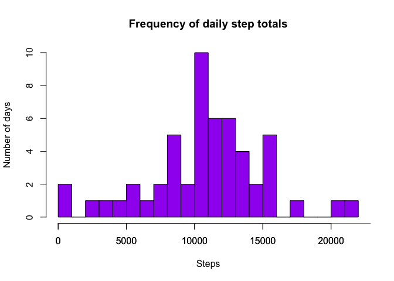

```r
hist(byday$x,
   breaks = 25,
   col = "purple",
   main = "Frequency of daily step totals",
   xlab = "Steps",
   ylab = "Number of days")
axis(side = 1,
   at = seq(0, 25000, 5000),
   labels = seq(0, 25000, 5000))
```

From this, we can see that the range goes from a couple days having less than 1000 steps to a couple days having more than 20,000 steps. The largest number of days (10) had between 10,000 and 11,000 steps.

```r
stepsmean <- mean(byday$x, na.rm = TRUE)
stepsmedian <- median(byday$x, na.rm = TRUE)
```

Across the measurement period, the mean number of steps was 10766.1886792 and the median number of steps was 10765.

## What is the average daily activity pattern?

Looking across the days of the measurement period, we can get a picture of the average daily activity pattern.

```r
byinterval <- aggregate(dataset$steps, by = list(interval = dataset$interval),
            FUN = mean, na.rm = TRUE)
byinterval
```

```
##     interval           x
## 1          0   1.7169811
## 2          5   0.3396226
## 3         10   0.1320755
## 4         15   0.1509434
## 5         20   0.0754717
## 6         25   2.0943396
## 7         30   0.5283019
## 8         35   0.8679245
## 9         40   0.0000000
## 10        45   1.4716981
## 11        50   0.3018868
## 12        55   0.1320755
## 13       100   0.3207547
## 14       105   0.6792453
```

[output cut: 274 more lines]

We can plot this as a time series plot:

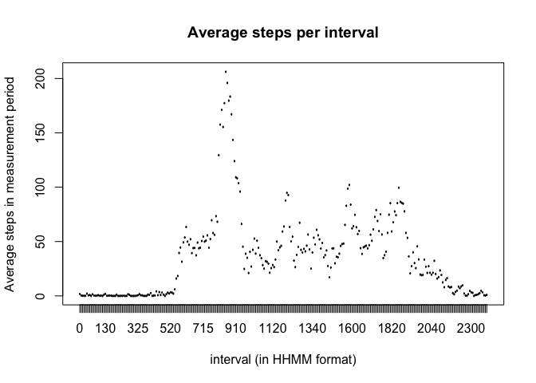

```r
plot(byinterval$interval, byinterval$x,
   type = 'l',
   main = "Average steps per interval",
   xlab = "interval (in HHMM format)",
   ylab = "Average steps in measurement period")
```

```r
largestinterval <- byinterval[which.max(byinterval$x), ]
```

During the study period, the most steps on average (206.1698113) occurred in the 835 interval.

## imputing missing values

Up until now, we have simply ignored days/intervals where no data was collected. This may introduce bias into our calculations, so we will fill in each NA interval record by using the mean for that interval across the measurement period.

```r
imputeddataset = cbind(dataset)
imputeddataset$steps = ifelse(is.na(imputeddataset$steps),
               byinterval$x,
               imputeddataset$steps)

imputedbyday <- aggregate(imputeddataset$steps, by = list(Date = imputeddataset$date),
             FUN = sum)
```

Now, we can make a new histogram and calculate the new mean and median:

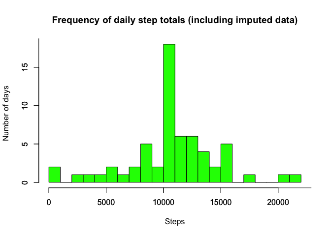

```r
hist(imputedbyday$x,
   breaks = 25,
   col = "green",
   main = "Frequency of daily step totals (including imputed data)",
   xlab = "Steps",
   ylab = "Number of days")
axis(side = 1,
   at = seq(0, 25000, 5000),
   labels = seq(0, 25000, 5000))
axis(side = 2,
   at = seq(0, 25, 5),
   labels = seq(0, 25, 5))
```

```r
imputedStepsMean <- mean(imputedbyday$x)
imputedStepsMedian <- median(imputedbyday$x)
```

After imputing the missing data, the new mean is 10766.1886792 and the new median is 10766.1886792. In this case, the mean remains the same (which makes sense, as NA records only appeared in days where the whole day was all NA records. Thus, we added 8 more days, each with the average daily total of steps.). The median value shifts slightly higher to be the same as the mean, again reflecting the addition of 8 more days all right at the average value.

In this case, the impact of imputing missing data by using the average for the missing interval is minimal, just shifting the median closer to the average.

## Are there differences in activity patterns betien weekdays and weekends?

By sorting the data based on whether the day was a weekday or weekend, we can see if our study subject has a different pattern of activity during the week versus on Saturday or Sunday.

```r
setDayType <- function(value) {
    day <- weekdays(as.Date(value, "%Y-%m-%d"))
    return_val <- ifelse(day == 'Saturday' || day == 'Sunday',
        'weekend', 'weekday')
    return_val
}

imputeddataset$daytype <- as.factor(sapply(imputeddataset$date, setDayType))
```